# Workshop

# Set working directory

```r
library(knitr)
opts_knit$set(root.dir = normalizePath("/ufrc/strauss/andrea.nuzzo/projects/Workshop"))
```

# Visualizations

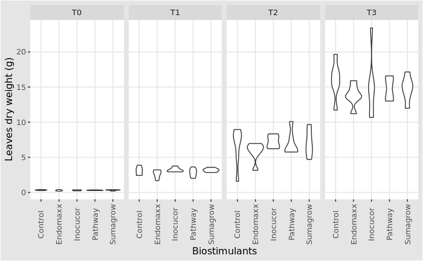

```r
library(tidyverse)
library(ggthemes)
plant_data <- read.csv('plant_data.csv', header = TRUE)
ggplot(plant_data,
       aes(x=Biostimulant,
           y=Leaves/1000))+ #,fill=TimePoint)) +
  facet_grid(.~TimePoint) +
  geom_violin() +
  xlab('Biostimulants') +
  ylab('Leaves dry weight (g)') + theme_igray() +
  theme(axis.text.x  = element_text(angle=90, vjust=0.5)) +
  scale_fill_pander()
```

# Data Cleaning

```r
##Check NANs
colSums(is.na(plant_data))
```

```
  X.SampleID    TimePoint Biostimulant          Rep         Area     SPAD.avg       Leaves
           0            0            0            0            1            0            1
       Stems         Root          Tot
           0            0            0
```

```r
plant_data[!complete.cases(plant_data),]
```

|  | X.SampleID | TimePoint | Biostimulant | Rep | Area | SPAD.avg | Leaves | Stems | Root | Tot |
| --- | --- | --- | --- | --- | --- | --- | --- | --- | --- | --- |
| 2 | B2CT0-2 | T0 | Control | 2 | NA | 45.17 | 412 | 265 | 129 | 806 |
| 31 | B2CT1-1 | T1 | Control | 1 | 706.44 | 55.00 | NA | 1223 | 1112 | 5220 |

## Imputing missing data

```r
##Imputing NANs with averages of subsets of the data (based on timepoint and biostimulants, thus taking the mean from replicates of the same missing sample)
plant_data$Area <- ifelse(is.na(plant_data$Area),
                      ave(plant_data[(plant_data$TimePoint==plant_data[which(is.na(plant_data$Area)),'TimePoint'] & plant_data$Biostimulant==plant_data[which(is.na(plant_data$Area)),'Biostimulant']),'Area'],
                                 FUN = function(x) mean(x, na.rm = TRUE)),plant_data$Area)
plant_data$Leaves <- ifelse(is.na(plant_data$Leaves),
                      ave(plant_data[(plant_data$TimePoint==plant_data[which(is.na(plant_data$Leaves)),'TimePoint'] & plant_data$Biostimulant==plant_data[which(is.na(plant_data$Leaves)),'Biostimulant']),'Leaves'],
                                 FUN = function(x) mean(x, na.rm = TRUE)),plant_data$Leaves)
##Check NANs
colSums(is.na(plant_data))
```

```
  X.SampleID    TimePoint Biostimulant          Rep         Area     SPAD.avg       Leaves
           0            0            0            0            0            0            0
       Stems         Root          Tot
           0            0            0
```

# Feature engineering

## Combine categorical variables

```r
lda_variables <- plant_data %>%
mutate(Biostimulant_TimePoint=paste(Biostimulant, TimePoint, sep = '_'))
```

## LDA Area vs TimePoint

```r
library(MASS)
area_vs_treatment_set = dplyr::select(plant_data, Area, TimePoint)
# Feature Scaling
area_vs_treatment_set[1] = scale(area_vs_treatment_set[1])
# Applying LDA
lda_area_vs_treatment = lda(formula = TimePoint ~ Area,
                              data = area_vs_treatment_set)
area_vs_treatment_results = as.data.frame(predict(lda_area_vs_treatment, area_vs_treatment_set))
area_vs_treatment_results = area_vs_treatment_results[c(6, 1)]
names(area_vs_treatment_results) <- c('LDA1_area_vs_treatment')
# Check how much variance the LDA covers
lda_area_vs_treatment$svd^2/sum(lda_area_vs_treatment$svd^2)
```

```
[1] 1
```

```r
lda_variables <- cbind(lda_variables, area_vs_treatment_results[1])
```

## LDA Biomass vs Timepoint

```r
biomass_vs_treatment_set = dplyr::select(plant_data, Leaves, Root, Stems, TimePoint)
# Feature Scaling
biomass_vs_treatment_set[-4] = scale(biomass_vs_treatment_set[-4])
# Applying LDA
lda_biomass_vs_treatment = lda(formula = TimePoint ~ Leaves+Root+Stems,
                              data = biomass_vs_treatment_set)
biomass_vs_treatment_results = as.data.frame(predict(lda_biomass_vs_treatment, biomass_vs_treatment_set))
biomass_vs_treatment_results = biomass_vs_treatment_results[c(6,7,8,1)]
names(biomass_vs_treatment_results) <- c('LDA1_biomass_vs_treatment')
lda_biomass_vs_treatment$svd^2/sum(lda_biomass_vs_treatment$svd^2)
```

```
[1] 0.972823981 0.025374543 0.001801476
```

```r
lda_variables <- cbind(lda_variables, biomass_vs_treatment_results[1])
```

# Statistical exploratory analysis

## Correlation plots

[output not shown]

[output cut: 617 more lines]

[output not shown]

[figure not shown]

```r
library(corrplot)
dummyvars <- model.matrix(X.SampleID~Biostimulant+Biostimulant_TimePoint,lda_variables)
encoded_vars <- cbind(dummyvars[,-1], lda_variables[,which(names(lda_variables)!='LinkerPrimerSequence' &
                                                  names(lda_variables)!='BarcodeSequence' &
                                                  names(lda_variables)!='Description' &
                                                  names(lda_variables)!='InputFileName' &
                                                  names(lda_variables)!='X.SampleID' &
                                                  names(lda_variables)!='Rep' &
                                                  names(lda_variables)!='Biostimulant' &
                                                  names(lda_variables)!='TimePoint' &
                                                  names(lda_variables)!='Biostimulant_TimePoint')])
corr.mat = cor(encoded_vars, use='complete.obs')
p.mat = cor.mtest(encoded_vars)$p
row.names(p.mat) <- row.names(corr.mat)
colnames(p.mat) <- colnames(corr.mat)
corrplot(corr.mat, type='lower',
         tl.pos = 'lt',
         addCoefasPercent = TRUE,
         method = 'square',
         number.cex = .4, tl.cex = 0.8,
         order = 'FPC',  tl.col="black",
         p.mat = p.mat, sig.level = 0.01,
         insig = 'label_sig',
         pch.cex = .3,
         pch = '*') +
corrplot(p.mat, type = 'upper', add = T, tl.pos = 'n', method = 'circle',
         col =rainbow(40, start = 5/6, end = 4/6), cl.lim =c(0,1), diag = FALSE)
```

## Tukey’s HSD

```r
library(agricolae)
formula <- lda_variables %>%
  dplyr::select(-X.SampleID, -Biostimulant, -TimePoint, -Rep, -Biostimulant_TimePoint) %>%
  colnames(.) %>%
  paste(collapse = '+') %>%
  paste0("~Biostimulant*TimePoint")
model <- aov(formula = as.formula(formula),data = lda_variables)
HSD.test(model, c('Biostimulant','TimePoint'), group=TRUE, console = TRUE)
```

```
Study: model ~ c("Biostimulant", "TimePoint")

HSD Test for Area + SPAD.avg + Leaves + Stems + Root + Tot + LDA1_area_vs_treatment + LDA1_biomass_vs_treatment

Mean Square Error:  59860423

Biostimulant:TimePoint,  means
```

|  | Area...SPAD.avg...Leaves...Stems...Root...Tot...LDA1_area_vs_treatment...LDA1_biomass_vs_treatment | std | r | Min | Max |
| --- | --- | --- | --- | --- | --- |
| Control:T0 | 1423.980 | 209.6647 | 6 | 1127.5490 | 1753.384 |
| Control:T1 | 11221.281 | 1608.8545 | 6 | 9160.6688 | 13159.208 |
| Control:T2 | 27919.769 | 11827.2449 | 6 | 6182.1711 | 38148.368 |
| Control:T3 | 90523.541 | 11282.4934 | 6 | 71122.3143 | 103970.407 |
| Endomaxx:T0 | 1233.455 | 336.6803 | 6 | 749.9229 | 1716.401 |
| Endomaxx:T1 | 10655.031 | 2569.9170 | 6 | 6252.4763 | 13009.854 |
| Endomaxx:T2 | 28458.386 | 8004.2091 | 6 | 12648.9982 | 35096.270 |
| Endomaxx:T3 | 79857.140 | 6390.8685 | 6 | 68436.2083 | 87294.333 |
| Inocucor:T0 | 1351.726 | 164.4797 | 6 | 1149.8716 | 1536.325 |
| Inocucor:T1 | 13246.916 | 757.6288 | 6 | 12368.0014 | 14399.580 |

[output cut: 10 more lines]

```
Alpha: 0.05 ; DF Error: 100
Critical Value of Studentized Range: 5.148913

Minimun Significant Difference: 16263.34

Treatments with the same letter are not significantly different.
```

|  | Area + SPAD.avg + Leaves + Stems + Root + Tot + LDA1_area_vs_treatment + LDA1_biomass_vs_treatment | groups |
| --- | --- | --- |
| Control:T3 | 90523.541 | a |
| Sumagrow:T3 | 87026.510 | a |
| Pathway:T3 | 86753.210 | a |
| Inocucor:T3 | 86171.488 | a |
| Endomaxx:T3 | 79857.140 | a |
| Pathway:T2 | 33673.238 | b |
| Sumagrow:T2 | 32320.106 | b |
| Inocucor:T2 | 31142.004 | b |
| Endomaxx:T2 | 28458.386 | bc |
| Control:T2 | 27919.769 | bcd |

[output cut: 10 more lines]

```r
readr::write_tsv(lda_variables,'mappings_LDA.txt')
```

# Phyloseq

## Import files

```r
library(phyloseq)
library(vegan)
library(ape)
library(dummies)
#File Paths
biom_path <- file.path('merged/biom/table_wo_chl_mit.biom')
tree_path <- file.path('merged/biom/tree.nwk')
DESEq2_path <- file.path('merged/biom/DESeq2_w_tax.biom')
map_path <- file.path('mappings_LDA.txt')
#Import to phyloseq table and merge into phyloseq objects
table <- import_biom(BIOMfilename = biom_path,
                      #refseqfilename = repseqfile,
                      parseFunction = parse_taxonomy_default,
                      parallel = T)
```

```
input string 1 is invalid in this locale
```

```r
tax_table(table) <-tax_table(table)[,1:7]
DESEq2.table <- import_biom(BIOMfilename = DESEq2_path,
                      #refseqfilename = repseqfile,
                      parseFunction = parse_taxonomy_default,
                      parallel = T)
```

```
input string 1 is invalid in this locale
```

```r
tax_table(DESEq2.table) <-tax_table(DESEq2.table)[,1:7]
metadata <- import_qiime_sample_data(map_path)
tree <- read_tree(tree_path)
phylobj <- merge_phyloseq(table, metadata, tree)
DESEq2.phylobj <- merge_phyloseq(DESEq2.table, metadata, tree)
#Adjust taxonomy names (to harmonize betwen UNITE and SILVA databases)
tax_table(phylobj) <- gsub(".*__", "", tax_table(phylobj))
colnames(tax_table(phylobj)) <- c("Kingdom", "Phylum", "Class",
                    "Order", "Family", "Genus", "Species")
tax_table(DESEq2.phylobj) <- gsub(".*__", "", tax_table(DESEq2.phylobj))
colnames(tax_table(DESEq2.phylobj)) <- c("Kingdom", "Phylum", "Class",
                    "Order", "Family", "Genus", "Species")
#Log-transform sample counts (if needed)
pslog <- transform_sample_counts(phylobj,function(x){log(1 + x)})
```

## Phylum barplots

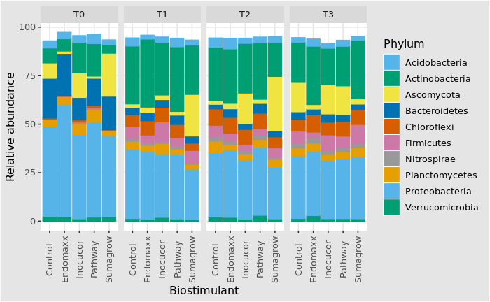

```r
phyloglom <- tax_glom(phylobj, 'Phylum')
phylorel <- transform_sample_counts(phyloglom, function(x){100*x/sum(x)})
phylorel %>%
  filter_taxa(function(x){ mean(x) > 1}, TRUE) %>%
  psmelt()%>%
  group_by(Biostimulant, TimePoint, Phylum) %>%
  summarize(mean=mean(Abundance)) %>%
  ggplot() +
  aes(x=Biostimulant, y=mean, fill=Phylum, color=Phylum) +
  geom_bar(stat='identity') +
  facet_grid(.~TimePoint) +
  ylab('Relative abundance') +
  theme_igray() +
  theme(axis.text.x  = element_text(angle=90, vjust=0.5)) +
  scale_fill_pander() + scale_color_pander()
```

```r
NA
```

## Alpha Diveristy

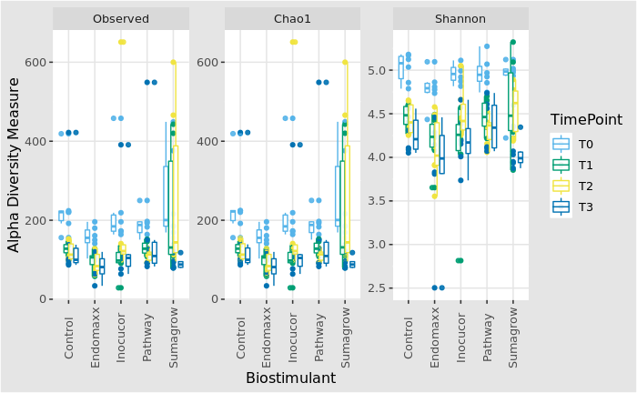

```r
plot_richness(phylobj,
              x = "Biostimulant",
              color = "TimePoint",
              measures = c('Observed', 'Chao1', 'Shannon')) +
  geom_boxplot(alpha=.9) + theme_igray() +
  theme(axis.text.x  = element_text(angle=90, vjust=0.5))+
  scale_color_pander() + scale_fill_pander()
```

## Rarefaction plots

[output not shown]

[output cut: 65 more lines]

[output not shown]

[figure not shown]

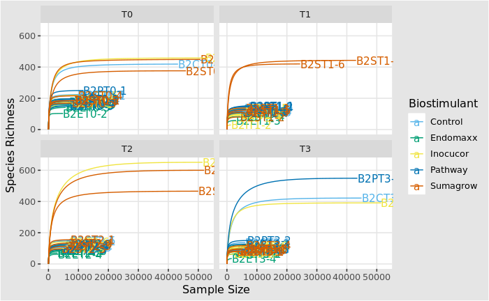

```r
source('https://raw.githubusercontent.com/mahendra-mariadassou/phyloseq-extended/master/R/richness.R')
ggrare(phylobj, step = 100, color = "Biostimulant", label = "Sample", se = FALSE) +
  facet_wrap(~TimePoint) + guides(label=FALSE) + theme_igray() + scale_color_pander()
```

## PCoA with Bray distances

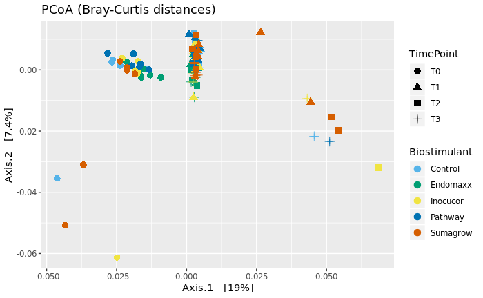

```r
PCoA.bray.ord<- ordinate(DESEq2.phylobj, "PCoA", distance = "bray")
PCoA.bray.plot <- plot_ordination(physeq = pslog,
                                        ordination = PCoA.bray.ord,
                                        color = "Biostimulant",
                                        shape = "TimePoint",
                                        title = "PCoA (Bray-Curtis distances)")
PCoA.bray.plot +geom_point(size=3) + scale_color_pander()
```

## PCoA with Unifrac distances

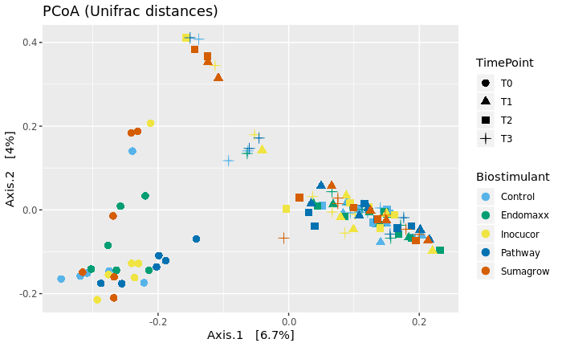

```r
PCoA.bray.ord<- ordinate(pslog, "PCoA", distance = "unifrac")
PCoA.bray.plot <- plot_ordination(physeq = pslog,
                                        ordination = PCoA.bray.ord,
                                        color = "Biostimulant",
                                        shape = "TimePoint",
                                        title = "PCoA (Unifrac distances)")
PCoA.bray.plot +geom_point(size=3) + scale_color_pander()
```

If you want to run PCoA with ALL possible distances (adapted from Phyloseq website https://joey711.github.io/phyloseq/distance.html) (requires a lot of memory)

```r
dist_methods <- unlist(distanceMethodList)
dist_methods = dist_methods[-which(dist_methods=="ANY")]

plist <- vector("list", length(dist_methods))
names(plist) = dist_methods
for( i in dist_methods ){
    # Calculate distance matrix
    iDist <- distance(pslog, method=i)
    # Calculate ordination
    iMDS  <- ordinate(pslog, "PCoA", distance=iDist)
    ## Make plot
    # Don't carry over previous plot (if error, p will be blank)
    p <- NULL
    # Create plot, store as temp variable, p
    p <- plot_ordination(pslog, iMDS, color="Biostimulant", shape="TimePoint")
    # Add title to each plot
    p <- p + ggtitle(paste("PCoA using distance method ", i, sep=""))
    # Save the graphic to file.
    plist[[i]] = p
}

df = ldply(plist, function(x) x$data)
names(df)[1] <- "distance"
p = ggplot(df, aes(Axis.1, Axis.2, color=Biostimulant, shape=TimePoint))
p = p + geom_point(size=3, alpha=0.5)
p = p + facet_wrap(~distance, scales="free")
p = p + ggtitle("PCoA on various distance metrics")
p
```

## NMDS

```r
NMDS_bray_b1 <- ordinate(DESEq2.phylobj, method = "NMDS", distance = "bray")
```

```
Wisconsin double standardization
*** No convergence -- monoMDS stopping criteria:
    15: no. of iterations >= maxit
     5: stress ratio > sratmax
```

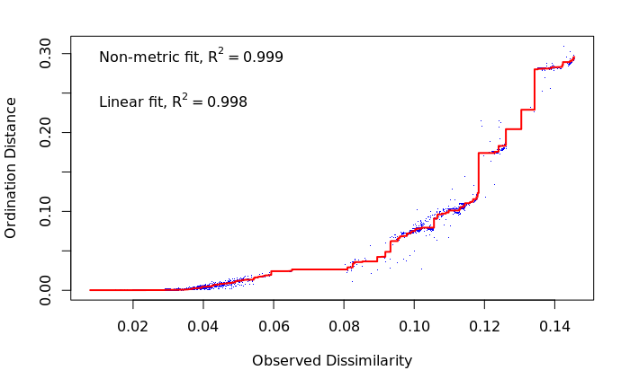

```r
stressplot(NMDS_bray_b1)
```

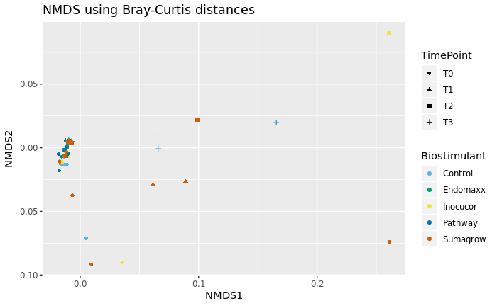

```r
plot_NMDS_bray_b1 <- plot_ordination(pslog,
                                  NMDS_bray_b1,
                                  type="samples",
                                  color="Biostimulant",
                                  shape="TimePoint")
plot_NMDS_bray_b1 + ggtitle("NMDS using Bray-Curtis distances") + scale_color_pander()
```

## PERMANOVA

```r
DESEq2.df = as(sample_data(DESEq2.phylobj), "data.frame")
DESEq2.distbray = distance(DESEq2.phylobj, "bray")
adonis(DESEq2.distbray ~ TimePoint*Biostimulant, DESEq2.df)
```

```
Call:
adonis(formula = DESEq2.distbray ~ TimePoint * Biostimulant,      data = DESEq2.df)

Permutation: free
Number of permutations: 999

Terms added sequentially (first to last)

                        Df SumsOfSqs
TimePoint                3  0.024838
Biostimulant             4  0.005316
TimePoint:Biostimulant  12  0.018086
Residuals              100  0.142798
Total                  119  0.191038
                         MeanSqs F.Model
TimePoint              0.0082795  5.7980
Biostimulant           0.0013289  0.9306
TimePoint:Biostimulant 0.0015072  1.0555
Residuals              0.0014280
Total
                            R2 Pr(>F)
TimePoint              0.13002  0.001 ***
Biostimulant           0.02783  0.704
TimePoint:Biostimulant 0.09467  0.221
Residuals              0.74748
Total                  1.00000
---
Signif. codes:
0 ‘***’ 0.001 ‘**’ 0.01 ‘*’ 0.05 ‘.’ 0.1 ‘ ’ 1
```

## ANOSIM and beta dispersivity

```r
attach(metadata)
NMDS_anosim = anosim(DESEq2.distbray, Biostimulant)
summary(NMDS_anosim)
```

```
Call:
anosim(x = DESEq2.distbray, grouping = Biostimulant)
Dissimilarity: bray

ANOSIM statistic R: 0.003099
      Significance: 0.242

Permutation: free
Number of permutations: 999

Upper quantiles of permutations (null model):
    90%     95%   97.5%     99%
0.00747 0.01020 0.01328 0.01840

Dissimilarity ranks between and within classes:
          0%     25%    50%     75% 100%    N
Between    1 1795.50 3576.5 5360.50 7140 5760
Control  114 2125.00 4360.0 5730.75 7139  276
Endomaxx 771 2953.25 4398.5 6281.00 7135  276
Inocucor   8 1840.50 3811.5 5355.00 7059  276
Pathway   45 1690.75 3539.5 5610.25 7124  276
Sumagrow  13  906.25 2010.0 3533.75 5491  276
```

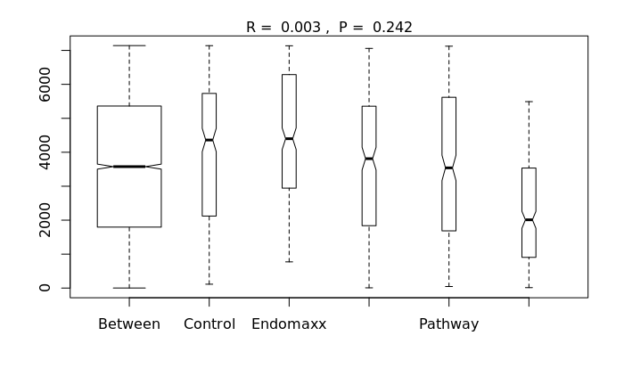

```r
plot(NMDS_anosim)
```

```r
beta <- betadisper(DESEq2.distbray, DESEq2.df$Biostimulant)
permutest(beta)
```

```
Permutation test for homogeneity of
multivariate dispersions
Permutation: free
Number of permutations: 999

Response: Distances
           Df   Sum Sq    Mean Sq      F
Groups      4 0.004390 0.00109760 2.6446
Residuals 115 0.047728 0.00041503
          N.Perm Pr(>F)
Groups       999  0.039 *
Residuals
---
Signif. codes:
0 ‘***’ 0.001 ‘**’ 0.01 ‘*’ 0.05 ‘.’ 0.1 ‘ ’ 1
```

## CCA with VIF selection

```r
source('https://andreanuzzo.github.io/Strausslab/vif.cca.bw_sel.R')
vifvariables = lda_variables
vifvariables = vifvariables[,which(names(vifvariables)!='LinkerPrimerSequence' &
                        names(vifvariables)!='BarcodeSequence' &
                        names(vifvariables)!='Description' &
                        names(vifvariables)!='InputFileName' &
                        names(vifvariables)!='X.SampleID' &
                        names(vifvariables)!='Batch' &
                        names(vifvariables)!='Rep')]
cca_vif <- vif.cca.bw_sel(DESEq2.phylobj, vifvariables, threshold = 5)
```

```
[1] "Removing variable Root with VIF:167.88"
[1] "Removing variable LDA1_biomass_vs_treatment with VIF:130.9"
[1] "Removing variable Stems with VIF:79.5"
[1] "Removing variable TimePointT3 with VIF:25.48"
[1] "Removing variable Leaves with VIF:22.74"
[1] "Removing variable BiostimulantSumagrow with VIF:11.68"
```

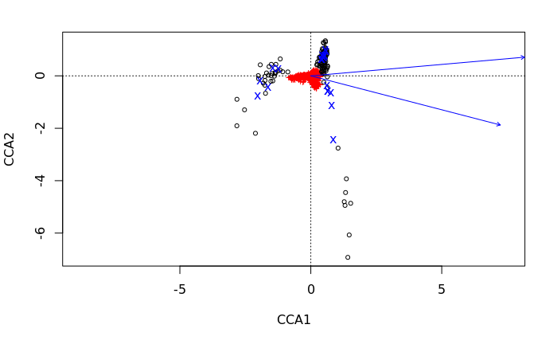

```r
plot(cca_vif)
```

```r
anova(cca_vif)
```

```
Permutation test for cca under reduced model
Permutation: free
Number of permutations: 999

Model: cca(formula = OTU ~ Area + SPAD.avg + Biostimulant_TimePoint + LDA1_area_vs_treatment, data = data)
         Df ChiSquare     F Pr(>F)
Model    21  0.038904 1.349  0.001 ***
Residual 98  0.134584
---
Signif. codes:
0 ‘***’ 0.001 ‘**’ 0.01 ‘*’ 0.05 ‘.’ 0.1 ‘ ’ 1
```

## CCA plot

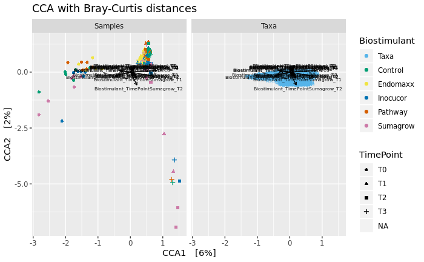

```r
cca_plot <- plot_ordination(physeq = pslog,
                            ordination = cca_vif,
                            type= 'split',
                            color = "Biostimulant",
                            label = 'Phylum'
                            ) + aes(shape = TimePoint) +
geom_point(aes(colour = Biostimulant))
cca_arrowmat <- scores(cca_vif, display = "bp")
cca_arrowdf <- data.frame(labels = rownames(cca_arrowmat), cca_arrowmat)
cca_arrow_map <- aes(xend = CCA1,
                 yend = CCA2,
                 x = 0,
                 y = 0,
                 color = NULL,
                 shape = NULL)
cca_label_map <- aes(x = 1.3 * CCA1,
                 y = 1.3 * CCA2,
                 color = NULL,
                 label = labels,
                 shape = NULL)
cca_arrowhead = arrow(length = unit(0.02, "npc"))
cca_plot + geom_segment(mapping = cca_arrow_map, size = .5, data = cca_arrowdf,
               color = "black", arrow = cca_arrowhead) +
  geom_text(mapping = cca_label_map, size = 2, data = cca_arrowdf) +
  ggtitle("CCA with Bray-Curtis distances") + scale_color_pander()
```

## CAP Plot

```r
source('https://andreanuzzo.github.io/Strausslab/vif.cap.bw_sel.R')
cap_vif <- vif.cap.bw_sel(pslog, vifvariables, threshold = 5)
```

```
[1] "Removing variable Root with VIF:167.19"
[1] "Removing variable LDA1_biomass_vs_treatment with VIF:130.4"
[1] "Removing variable Stems with VIF:79.59"
[1] "Removing variable TimePointT3 with VIF:25.45"
[1] "Removing variable Leaves with VIF:22.6"
[1] "Removing variable BiostimulantSumagrow with VIF:11.48"
```

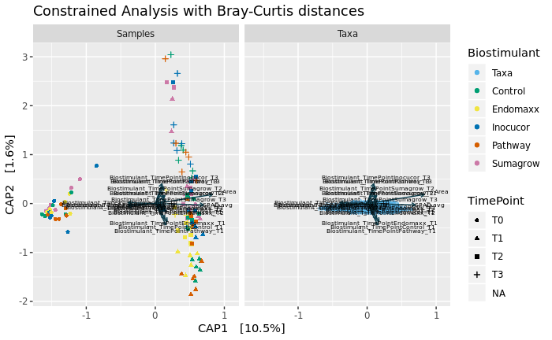

```r
cap_plot <- plot_ordination(physeq = pslog,
                            ordination = cap_vif,
                            type= 'split',
                            color = "Biostimulant",
                            label = 'Phylum',
                            axes = c(1,2)) +
  aes(shape = TimePoint) +
  geom_point(aes(colour = Biostimulant)) + scale_color_pander()
arrowmat <- scores(cap_vif, display = "bp")
arrowdf <- data.frame(labels = rownames(arrowmat), arrowmat)
arrow_map <- aes(xend = CAP1,
                 yend = CAP2,
                 x = 0,
                 y = 0,
                 color = NULL,
                 shape = NULL)
label_map <- aes(x = 1.3 * CAP1,
                 y = 1.3 * CAP2,
                 color = NULL,
                 label = labels,
                 shape = NULL)
arrowhead = arrow(length = unit(0.02, "npc"))
cap_plot +
  geom_segment(mapping = arrow_map, size = .5, data = arrowdf,
               color = "#0C3D4C", arrow = arrowhead) +
  geom_text(mapping = label_map, size = 2, data = arrowdf, show.legend = FALSE) +
  ggtitle("Constrained Analysis with Bray-Curtis distances")
```

# Network analysis with SpiecEasi

## Import libraries

```r
library(SpiecEasi)
library(igraph)
library(indicspecies)
```

We will work on the log-normalized table that we produced in the merged pipeline, containing both fungal and bacterial features, and which has undergone a prefiltering process. Then we get rid of all the zeroes in case there are some left. Then remove the taxa with zero abundance and we create a dummy taxon with the sum of the taxa (necessary for SpiecEasi).

```r
minocc = round(nrow(sample_data(DESEq2.phylobj))/6)
minocc_taxa <- filter_taxa(DESEq2.phylobj, function(x) sum(x > mean(x)) > (0.05*length(x)), TRUE)
extra_taxa <- setdiff(taxa_names(DESEq2.phylobj), taxa_names(minocc_taxa))
extra_taxa <- prune_taxa(extra_taxa, DESEq2.phylobj)
otus <- rbind(otu_table(minocc_taxa), taxa_sums(otu_table(extra_taxa)))
otus.f=as.matrix(otus)
taxa=tax_table(DESEq2.phylobj)
taxa.f=taxa[setdiff(1:nrow(taxa),taxa_names(extra_taxa)),]
dummyTaxonomy=c("k__dummy","p__","c__","o__","f__","g__","s__")
taxa.f=rbind(taxa.f,dummyTaxonomy)
rownames(taxa.f)[nrow(taxa.f)]="0"
rownames(otus.f)[nrow(otus.f)]="0"
updatedotus=otu_table(otus.f, taxa_are_rows = TRUE)
updatedtaxa=tax_table(taxa.f)
DESEq2.phylobj.f=phyloseq(updatedotus, updatedtaxa, metadata)
```

## Preliminary network

Now a first network (which will be randomly arranged at this stage), colored by Kingdom (takes a while)

```r
spiec.out=spiec.easi(DESEq2.phylobj.f, method="mb",icov.select.params=list(rep.num=10, ncores=3))
```

```
Normalizing/clr transformation of data with pseudocount ...
Inverse Covariance Estimation with mb ...
Model selection with stars ...
Done!
```

```
attributes are not identical across measure variables; they will be dropped
```

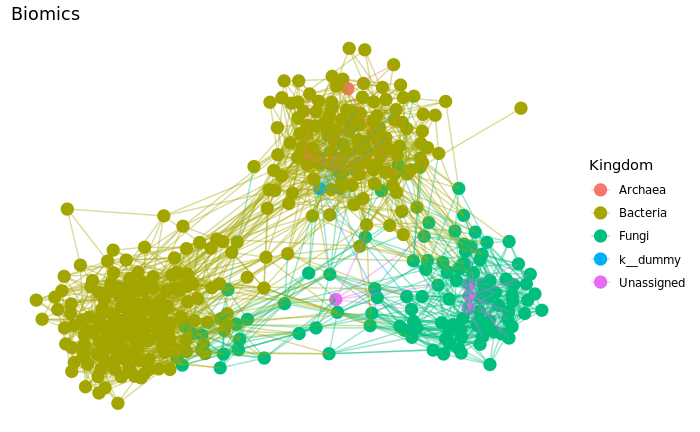

```r
spiec.graph=adj2igraph(spiec.out$refit, vertex.attr=list(name=taxa_names(DESEq2.phylobj.f)))
plot_network(spiec.graph, DESEq2.phylobj.f, type='taxa', label=NULL, title = "Biomics", color = "Kingdom")
```

## Fast greedy algorithm

Now using the fast greedy algorithm to cluster the network. Greedy algorithms start by random points, and then increase the network without considering all the possible next points but taking the shortest path they encounter and then moving to the next point. This is quick, but it might lead to shorter paths than other algorithms. Once the clusters are individuated, then I show the counts of the phyla composing the 1st and 2nd biggest clusters.

```r
clusters=cluster_fast_greedy(spiec.graph)
clusterOneIndices=which(clusters$membership==1)
clusterOneOtus=clusters$names[clusterOneIndices]
clusterTwoIndices=which(clusters$membership==2)
clusterTwoOtus=clusters$names[clusterTwoIndices]
print("Phyla in cluster 1")
```

```
[1] "Phyla in cluster 1"
```

```r
sort(table(taxa.f[clusterOneOtus,]),decreasing = TRUE)
```

```
                              Bacteria                         Actinobacteria
                                   129                                    120
                        Proteobacteria                        Nocardioidaceae
                                    37                                     29
                   Propionibacteriales                   uncultured bacterium
                                    29                                     29
                        Ambiguous_taxa                    Alphaproteobacteria
                                    21                                     19
                    Betaproteobacteria                           Nocardioides
                                    17                                     17
                       Burkholderiales                           Streptomyces
                                    13                                     13
                     Streptomycetaceae                       Streptomycetales
                                    13                                     13
                            uncultured              uncultured soil bacterium
                                    13                                     13
                           Bacillaceae                             Bacillales
                                    12                                     12
                               Bacilli                         Comamonadaceae
                                    12                                     12
                            Firmicutes                          Micrococcales
                                    12                                     12
                           Rhizobiales                               Bacillus
                                    11                                      8
                           Marmoricola                             Nitrospira
                                     8                                      8
                      Sphingomonadales                                  Fungi
                                     8                                      7
                    Intrasporangiaceae                            Ramlibacter
                                     7                                      7
                            Ascomycota                            Chloroflexi
                                     5                                      5
                        Micrococcaceae                      Sphingomonadaceae
                                     5                                      5
                           Terrabacter                          Aeromicrobium
                                     5                                      4
                         Fictibacillus                         Nitrospiraceae
                                     4                                      4
                           Nitrospirae                          Nitrospirales
                                     4                                      4
```

[output cut: 59 more lines]

```
                                     1                                      1
                                   p__                      Planctomycetaceae
                                     1                                      1
                      Planctomycetacia                       Planctomycetales
                                     1                                      1
                        Planctomycetes                       Pyrenochaetopsis
                                     1                                      1
           Pyrenochaetopsis_leptospora                              Ralstonia
                                     1                                      1
                                   s__                                SC-I-84
                                     1                                      1
                           Sphingobium                      Trichoderma_lixii
                                     1                                      1
           Trichoderma_longibrachiatum                        Xanthomonadales
                                     1                                      1
```

```r
print("Phyla in cluster 2")
```

```
[1] "Phyla in cluster 2"
```

```r
sort(table(taxa.f[clusterTwoOtus,]),decreasing = TRUE)
```

```
           Bacteria      Proteobacteria  Betaproteobacteria     Burkholderiales
                  3                   3                   2                   2
     Comamonadaceae Alphaproteobacteria      Ambiguous_taxa         Sphingobium
                  2                   1                   1                   1
  Sphingomonadaceae    Sphingomonadales
                  1                   1
```

Replot the network for a better visualization, colored by Phylum

```
attributes are not identical across measure variables; they will be dropped
```

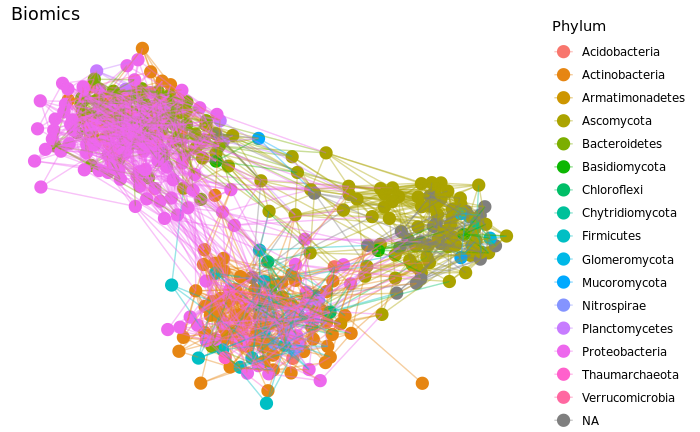

```r
plot_network(spiec.graph, subset_taxa(DESEq2.phylobj.f,
                                      Kingdom != "k__dummy" &
                                      Kingdom != "Unassigned" &
                                      Kingdom != "NA"),
             type='taxa', color="Phylum", label=NULL, title = "Biomics")
```

## Directed network

```r
#Construct the beta matrix (from spiec.easi output) and simmetrize
betaMat=as.matrix(symBeta(getOptBeta(spiec.out)))
#Define positive and negative interactions
positive=length(betaMat[betaMat>0])/2
negative=length(betaMat[betaMat<0])/2
total=length(betaMat[betaMat!=0])/2
print(paste("Out of", total, "edges, this network has",
            positive, "positive edges and",
            negative, "negative edges"))
```

```
[1] "Out of 2005 edges, this network has 1854 positive edges and 151 negative edges"
```

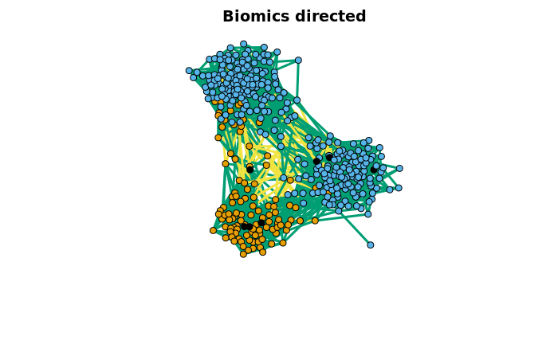

```r
#Define data
otu.ids=colnames(spiec.out$data)
edges=E(spiec.graph)
edge.colors=c()
#Function to assign per each edge a different color if positive or negative
for(e.index in 1:length(edges)){
  adj.nodes=ends(spiec.graph,edges[e.index])
  xindex=which(otu.ids==adj.nodes[1])
  yindex=which(otu.ids==adj.nodes[2])
  beta=betaMat[xindex,yindex]
  if(beta>0){
    edge.colors=append(edge.colors,categorical_pal(4)[3])
  }else if(beta<0){
    edge.colors=append(edge.colors,categorical_pal(4)[4])
  }
}
#Apply function
E(spiec.graph)$color=edge.colors
spiec.graph.b=spiec.graph
#Obtain kingdom nodes
E(spiec.graph.b)$arrow.size=5
vertexking=unique(tax_table(DESEq2.phylobj.f)[,1])
colbar <- categorical_pal(length(vertexking))
#Assign colors to the nodes by kingdom manually (I know...)
for(i in 1:length(components(spiec.graph.b)$membership)){
  OTU = names(components(spiec.graph.b)$membership[i])
  if(as.character(tax_table(DESEq2.phylobj.f)[OTU][,1]) == "Fungi"){
    V(spiec.graph.b)$color[i] <- colbar[1]
  } else if(as.character(tax_table(DESEq2.phylobj.f)[OTU][,1]) == "Bacteria"){
    V(spiec.graph.b)$color[i] <- colbar[2]
  } else {
    V(spiec.graph.b)$color[i] <- "black"
  }
}
#Plot
V(spiec.graph.b)$frame.color="black"
plot.igraph(spiec.graph.b, vertex.size=6, edge.width=3, vertex.label=NA, main="Biomics directed")
```

This is to save the files prior importing into Gephi. Before importing, remember to add for the spieceasi.X.csv file the first line which MUST be Source,Target,w (no quotes, no spaces); then add Id, before Kingdom in the X_lineages.csv. This will be your Node table file, while the other will be your Edge table file. Note that this will give UNDIRECTED networks (no positive or negative edges).

```r
write.table(taxa.f,file=file.path("lineages.csv"), sep=",", quote=FALSE)
write.graph(spiec.graph,file=file.path("spieceasi.txt"),format="ncol")
```

```r
sed -i  '' 's/ /,/g' spieceasi.txt
sed -i  '' '1i\
Source,Target,w
' spieceasi.txt
sed -i  '' 's/Kingdom,Phylum,Class,Order,Family,Genus,Species/Id,Kingdom,Phylum,Class,Order,Family,Genus,Species/g' lineages.csv
```

## Fragility

This is an example of a statistic you can derive from the network: fragility rate, which depends on the robustness, due to the connectivity. The network attack method prespecifies node order by hub characteristics (for example, degree and betweeness centrality) and assesses stability by natural connectivity (calculated as average eigenvalue of the graph adjacency matrix as the graph shrinks).

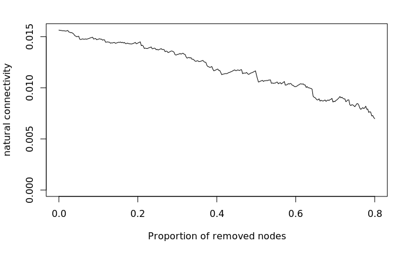

```r
#Define functions to get connectivity and eigenvalues
natcon <- function(ig) {
 N   <- vcount(ig)
 adj <- get.adjacency(ig)
 evals <- eigen(adj)$value
 nc  <- log(mean(exp(evals)))
 nc / (N - log(N))
}
#Define function to remove gradually nodes from the edges of the network
nc.attack <- function(ig) {
  hubord <- order(rank(betweenness(ig)), rank(degree(ig)), decreasing=TRUE)
  sapply(1:round(vcount(ig)*.8), function(i) {
    ind <- hubord[1:i]
    tmp <- delete_vertices(ig, V(ig)$name[ind])
    natcon(tmp)
  }) }
#Apply function
nc.ctl <- nc.attack(spiec.graph)
plot(seq(0,.8,len=length(nc.ctl)), nc.ctl, type='l', ylim=c(0,max(nc.ctl)), xlab="Proportion of removed nodes", ylab="natural connectivity")
```

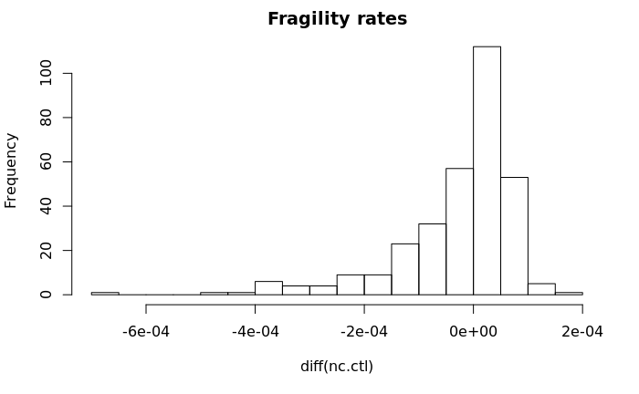

```r
hist(diff(nc.ctl), breaks=30, main="Fragility rates")
```

## Bipartite network.

A Bipartite network uses fake nodes that can be whatever catergory you choose in your metadata, and plots the associations with the relevant taxa. Here, we will be using the code from the paper of Hartmann et al. 2018

```r
#Find indicator species
indic_otu <- as.data.frame(t(otus.f))
indic_groups <- sample_data(DESEq2.phylobj.f)$Biostimulant
length(unique(indic_groups))
```

```
[1] 5
```

```r
set.seed(42)
indicatorsp <- multipatt(indic_otu,
                         indic_groups,
                         func = "r.g",
                         control=how(nperm=9999))
summary(indicatorsp, alpha=1,indvalcomp=T)
```

```
 Multilevel pattern analysis
 ---------------------------

 Association function: r.g
 Significance level (alpha): 1

 Total number of species: 399
 Selected number of species: 399
 Number of species associated to 1 group: 94
 Number of species associated to 2 groups: 170
 Number of species associated to 3 groups: 101
 Number of species associated to 4 groups: 34

 List of species associated to each combination:

 Group Control  #sps.  15
                                  stat p.value
6c90d5525ba76f1d2e10aaef19179548 0.330  0.0061 **
80f464dc28c65a8c24226a0bc7bf7cf2 0.314  0.0097 **
3f55e0d908b11462d04133dd8c7aa8bd 0.301  0.0085 **
49c3a7c03a6422ca99f374d7ac90a58c 0.296  0.0122 *
23730c47abc0f4512b502a360792d7e6 0.243  0.0857 .
41362df64ed3ebc134f8086fdb8c058c 0.234  0.0940 .
e471721dc9f26625e47ec36b5049b0d6 0.211  0.1645
dc0d6ab65bb6ec4c6d2865fe21943ea2 0.211  0.1593
67daced72c6dc9f126b24c7c66a06629 0.173  0.3888
f5dcebaad0ff3b1b3e07707d6510c4c9 0.172  0.3273
580f8fa7dfa69b31b2c5dca986baa8e9 0.155  0.4618
fc2a199e209e67cafadeda594f058fa6 0.143  0.6189
235bb39eaaca5dc67e60a6e2dc99d964 0.138  0.5968
5630add7aef7df494b4fac95f1dc4e59 0.129  0.6216
857cbd41225d10f8363435637e70e8dd 0.102  0.8450

 Group Endomaxx  #sps.  5
                                  stat p.value
916db4277246b5dd9bb7550196e13fc2 0.282  0.0255 *
14907d2b8ed251faf5f9414ba111af4d 0.266  0.0364 *
e9ccbee52e3f0072bdc85af9a316ae85 0.125  0.6964
efedd4fbad8473b92c4476c6de7749e0 0.062  0.9686
253515902bb32c699205e5b859ac3767 0.052  0.9844
```

[output cut: 450 more lines]

```
e8c159995dc697647741e8ce43361cbb 0.120  0.7398
063863199d26d6bf8b26b508d95905b4 0.111  0.8059
9e62ab8c8c403e126f285f0569424d95 0.107  0.8908
900373be5497d033daaf4941f87e00cc 0.089  0.9043
b05fdddafa73d0bfc64b1cc4661c49a9 0.071  0.9509
c7cac2c2c3d7a9138ff501f31a443283 0.066  0.9511

 Group Endomaxx+Inocucor+Pathway+Sumagrow  #sps.  4
                                  stat p.value
21dfa67918ace76e9a2fe63a67c309e4 0.142   0.636
de8112483ddb92d289dc2fcca6de5691 0.121   0.791
41d95cafdd9ea511ce6e7c9407493d0f 0.075   0.936
48e2293f92e90b26d1bd47dbb4f8ff7b 0.064   0.968
---
Signif. codes:  0 ‘***’ 0.001 ‘**’ 0.01 ‘*’ 0.05 ‘.’ 0.1 ‘ ’ 1
```

```r
#Export indicator species
indicsp_df <- indicatorsp$sign
write.table(indicsp_df,"indicsp_df.txt",sep="\t",quote=F)
#Add the extra nodes
indsp.Control <- as.matrix(indicsp_df[which(indicsp_df$s.Control == 1 &
                                              indicsp_df$p.value < 0.05),])
indsp.Endomaxx <- as.matrix(indicsp_df[which(indicsp_df$s.Endomaxx == 1 &
                                              indicsp_df$p.value < 0.05),])
indsp.Inocucor <- as.matrix(indicsp_df[which(indicsp_df$s.Inocucor == 1 &
                                              indicsp_df$p.value < 0.05),])
indsp.Pathway <- as.matrix(indicsp_df[which(indicsp_df$s.Pathway == 1 &
                                              indicsp_df$p.value < 0.05),])
indsp.Sumagrow <- as.matrix(indicsp_df[which(indicsp_df$s.Sumagrow == 1 &
                                               indicsp_df$p.value < 0.05),])
indsp <- rbind(indsp.Control, indsp.Endomaxx, indsp.Inocucor, indsp.Pathway, indsp.Sumagrow)
#Get an overview of the unique values
colnames(indsp)[1:5] <-levels(sample_data(DESEq2.phylobj.f)$Biostimulant)
range(indsp[,"stat"])
```

```
[1] 0.2574587 0.3300536
```

```r
length(unique(rownames(indsp)))
```

```
[1] 21
```

```r
length(unique(rownames(indsp)))/nrow(otus.f)
```

```
[1] 0.05263158
```

```r
#Create the dataframe from which the bipartite network will be built
bipartite_df <- data.frame(from= c(rep("Control",length(which(indsp[,"Control"]==1))),
                                     rep("Endomaxx",length(which(indsp[,"Endomaxx"]==1))),
                                     rep("Inocucor",length(which(indsp[,"Inocucor"]==1))),
                                     rep("Pathway",length(which(indsp[,"Pathway"]==1))),
                                     rep("Sumagrow",length(which(indsp[,"Sumagrow"]==1)))),
                                 to= c(rownames(indsp)[which(indsp[,"Control"]==1)],
                                       rownames(indsp)[which(indsp[,"Endomaxx"]==1)],
                                       rownames(indsp)[which(indsp[,"Inocucor"]==1)],
                                       rownames(indsp)[which(indsp[,"Pathway"]==1)],
                                       rownames(indsp)[which(indsp[,"Sumagrow"]==1)]),
                                 r= c(indsp[which(indsp[,"Control"]==1),"stat"],
                                      indsp[which(indsp[,"Endomaxx"]==1),"stat"],
                                      indsp[which(indsp[,"Inocucor"]==1),"stat"],
                                      indsp[which(indsp[,"Pathway"]==1),"stat"],
                                      indsp[which(indsp[,"Sumagrow"]==1),"stat"]))
bipartite_attrib <- data.frame(node=unique(rownames(indsp)),indicgroup=0)
#Get which indicator species belongs to the indicator groups
for (i in as.character(bipartite_attrib$node)){
  bipartite_attrib[bipartite_attrib$node==i,"indicgroup"] <- paste(colnames(indsp)[which(indsp[i,1:5]==1)],collapse = "_")
}
bipartite_attrib <- cbind(bipartite_attrib,taxa.f[as.character(bipartite_attrib$node),])
## Create bipartite network with igraph
bi_graph <- graph.data.frame(bipartite_df, directed=T)
#Assign names to nodes (vertexes)
V(bi_graph)$type <- V(bi_graph)$name %in% bipartite_df[,1]
#Duda_bi_graph <- simplify(Duda_bi_graph, remove.multiple=T, remove.loops=T)
#Export for gephi, will require the same modifications as before
write.graph(bi_graph,file=file.path("bi_graph.csv"),format="ncol")
```

```r
sed -i  '' 's/ /,/g' bi_graph.csv
sed -i  '' '1i\
Source,Target,w
' bi_graph.csv
```

# Machine Learning in Qiime2

## Input preparation

```r
#!/bin/bash

# ----------------SLURM Parameters----------------

#SBATCH -J q2_model_input
#SBATCH --time=1:00:00
#SBATCH --ntasks=1
#SBATCH -D /ufrc/strauss/andrea.nuzzo/projects/Workshop/merged
#SBATCH -o logs/4_prepare_input_%j.out
#SBATCH -A strauss

date;hostname;pwd

################################################################################
#
# This script will prepare the input table for the modelling
#
################################################################################

# ----------------Housekeeping--------------------
rm -r models
mkdir models
mkdir models/input
cd models

# ----------------Load Modules--------------------
module load qiime2

# ------------------Commands----------------------
qiime taxa filter-table \
  --i-table ../features/table.qza \
  --i-taxonomy ../features/taxonomy.qza \
  --p-exclude chloroplast,mithocondria \
  --o-filtered-table input/inptab.qza

cd input

#Check the merged table

qiime feature-table summarize  \
 --i-table inptab.qza  \
 --o-visualization table.qzv \
 --m-sample-metadata-file ../../../mapping_LDA.txt

 #Collapse taxa levels at genus level

 qiime taxa collapse \
 --i-table inptab.qza \
 --i-taxonomy ../../features/taxonomy.qza \
 --p-level 6 \
 --o-collapsed-table inptab_genus.qza

module unload qiime2

date
```

## Gneiss with OLS and LME

```r
#!/bin/bash

# ----------------SLURM Parameters----------------

#SBATCH -J q2_gneiss
#SBATCH --mem=20g
#SBATCH --time=21:00:00
#SBATCH --ntasks=1
#SBATCH -n 8
#SBATCH -D /ufrc/strauss/andrea.nuzzo/projects/Workshop/merged
#SBATCH -o logs/5a_q2_gneiss_%j.out
#SBATCH -A strauss

date;hostname;pwd

################################################################################
#
# This script performs Gneiss log-transformed balances, then  OLS or LME modelling on your data
#
################################################################################

# ----------------Housekeeping--------------------
cd models
rm -r gneiss
mkdir gneiss
cd gneiss

# ----------------Load Modules--------------------
module load qiime2

# ------------------Commands----------------------
 qiime feature-table filter-features \
   --i-table ../input/inptab.qza \
   --o-filtered-table filtered-table.qza \
   --p-min-samples 5

 qiime gneiss correlation-clustering \
   --i-table filtered-table.qza \
   --o-clustering hierarchy.qza

 qiime gneiss ilr-hierarchical \
   --i-table filtered-table.qza \
   --i-tree hierarchy.qza \
   --o-balances balances.qza

 qiime gneiss dendrogram-heatmap \
   --i-table filtered-table.qza \
   --i-tree hierarchy.qza \
   --m-metadata-file ../../../mappings_LDA.txt \
   --m-metadata-column Biostimulant \
   --p-color-map viridis \
   --o-visualization heatmap.qzv

 qiime gneiss ols-regression \
   --p-formula "TimePoint+Biostimulant+Biostimulant_TimePoint+Area+SPAD+Leaves+Stems+Root+Tot+LDA1_area_vs_treatment+LDA1_biomass_vs_treatment" \
   --i-table balances.qza \
   --i-tree hierarchy.qza \
   --m-metadata-file ../../../mappings_LDA.txt \
   --o-visualization regression_summary.qzv

 qiime gneiss lme-regression \
   --p-formula "Biostimulant+Area+SPAD+Leaves+Stems+Root+Tot+LDA1_area_vs_treatment+LDA1_biomass_vs_treatment" \
   --p-groups  TimePoint \
   --i-table balances.qza \
   --i-tree hierarchy.qza \
   --m-metadata-file ../../../mappings_LDA.txt \
   --o-visualization lme_all_vs_time.qzv

module unload qiime2

date
```

## Exctract Balances

### Option 1: one by one, qiime2 way

```r
#!/bin/bash

# ----------------SLURM Parameters----------------

#SBATCH -J q2_balance_tax
#SBATCH --mem=10g
#SBATCH --time=1:00:00
#SBATCH --ntasks=1
#SBATCH -n 2
#SBATCH -D /ufrc/strauss/andrea.nuzzo/projects/Workshop/merged
#SBATCH -o logs/5b_balance_taxonomy_%j.out
#SBATCH -A strauss

date;hostname;pwd

################################################################################
#
# Finally, we want to extract the taxonomy for the balances which were
# Significant in the previous steps
#
################################################################################

# ----------------Housekeeping--------------------
cd models/gneiss
rm -r y*.qzv

# ----------------Load Modules--------------------
module load qiime2

# ------------------QUESTIONS---------------------
# Before going on, try to look at the summary of the model and answer:
# How much is explained by the model? (R-squared)
# Does the model overfit? (pred_mse < model_mse)
# Do residuals show a trend? (if yes, you missed a variable)
# Are predicted in the residuals range? (Usually yes is expected for low R-squared)
# Do you have any significant balance in the OLS? (red in the heatmap)

# ------------------Commands----------------------
# If you have any significant balance and your model does not overfit, do the
# following for each balance to know who are the strains that significantly weigh
# for the chosen variable (i.e. Location)

qiime gneiss balance-taxonomy \
      --i-table composition.qza \
      --i-tree hierarchy.qza \
      --i-taxonomy ../../features/taxonomy.qza \
      --p-taxa-level 6 \
      --p-balance-name y0 \
      --m-metadata-file ../../../mappings_LDA.txt \
      --m-metadata-column TimePoint \
      --o-visualization y0_taxa_TimePoint.qzv

qiime gneiss balance-taxonomy \
          --i-table composition.qza \
          --i-tree hierarchy.qza \
          --i-taxonomy ../../features/taxonomy.qza \
          --p-taxa-level 6 \
          --p-balance-name y0 \
          --m-metadata-file ../../../mappings_LDA.txt \
          --m-metadata-column Area \
          --o-visualization y0_taxa_Area.qzv
date
```

### Option 2: Do a batch extraction with a python script and then analize the mastodontic csv file

I wrote a small python script that can be called through a bash job. As long as you kept the folder structure consistent with the Qiime2 tutorial it will work on your files as well. The script is hosted on GitHub so you can download and modify it if needed.

```r
#!/bin/bash

# ----------------SLURM Parameters----------------

#SBATCH -J q2_gneiss
#SBATCH --mem=20g
#SBATCH --time=21:00:00
#SBATCH --ntasks=1
#SBATCH -n 8
#SBATCH -D /ufrc/strauss/andrea.nuzzo/projects/Workshop/
#SBATCH -o merged/logs/5c_gneiss_extractor_%j.out
#SBATCH -A strauss

date;hostname;pwd

################################################################################
#
# Extraction of all balances having adjusted p-values<0.01 from the gneiss viz
#
################################################################################

module load qiime2/2018.6

wget -O merged/scripts/Balance_extractor.py https://andreanuzzo.github.io/Strausslab/Balance_extractor.py
merged/scripts/Balance_extractor.py

module purge
date
```

To elaborate the mastodontic file you had to use either R again or Tableau or similar. Excel will fail poorly.

```r
rel.abund <- transform_sample_counts(phylobj, function(x){x/sum(x)})
```

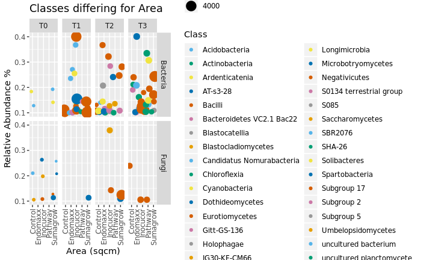

```r
subset_taxa(rel.abund, Genus %in% Area.balances$genus &
            !Kingdom =='Unassigned' & !Kingdom =='Archaea' & !Kingdom =='Plantae') %>%
  psmelt() %>%
  group_by(TimePoint, Biostimulant, Kingdom, Phylum, Class, Area) %>%
  summarize(mean=mean(Abundance, na.rm = TRUE)*100) %>%
  filter(mean>1e-1) %>%
  mutate(bin=ntile(Area,10)*round(min(Area, na.rm = TRUE),0)) %>%
  ggplot() +
      aes(x=Biostimulant, y = mean, colour=Class, size=bin) +
      geom_point(position = position_jitter()) +
      facet_grid(Kingdom~TimePoint) +
      labs(y = "Relative Abundance %", x = "Area (sqcm)") +
      theme(axis.text.x=element_text(angle=90,hjust=1,vjust=0.5),
            legend.box = 'vertical') +
      guides(color=guide_legend(ncol=2)) +
      scale_colour_discrete(guide = guide_legend(title.position = "top", nrow = 1)) +
      scale_color_pander()+
      ggtitle('Classes differing for Area')
```

### Option 3: Jupyter notebook

The other option is to use the Qiime2 API and use a Jupyter notebook or an RStudio notebook to elaborate the balances. Requires a bit of python knowledge (you can do it!)

```r
nano merged/scripts/jupyter_notebook.sh
```

And then

```r
#!/bin/bash

#----------SLURM Parameters-----------------#

#SBATCH --job-name=jupyter_andy
#SBATCH -D /ufrc/strauss/andrea.nuzzo/Workshop/merged
#SBATCH --account=strauss
#SBATCH --output=logs/jupyter_%j.log
#SBATCH --ntasks=1
#SBATCH --cpus-per-task=4
#SBATCH --mem=10gb
#SBATCH --time=72:00:00

date;hostname;pwd

module load qiime2/2018.6

jupyter-notebook --no-browser --port=23456 --ip='*'

date
```

```r
sbatch merged/scripts/jupyter_notebook.sh
```

Wait a couple of minutes. You will then have to open the log. You then need to open an ssh tunnel, using the address that the log gives you. It will appear as something like `The Jupyter Notebook is running at:http://(c23a-s40.ufhpc or 127.0.0.1):23456/`. Copy the part before ufhpc and complete this command in a new terminal window.

```r
ssh -NL 8000:c21b-s18.ufhpc:23456 your_email@hpg.rc.ufl.edu
```

You will be prompted with the request for password. After that, open a new Firefox window and digit `localhost:8000` to enter. If you didn’t set your password, use the token that it’s in the jupyter notebook log you open previously.

## Random Forest Analyses

```r
#!/bin/bash

# ----------------SLURM Parameters----------------

#SBATCH -J q2_RF
#SBATCH --mem=30g
#SBATCH --time=21:00:00
#SBATCH --ntasks=1
#SBATCH -n 8
#SBATCH -D /ufrc/strauss/andrea.nuzzo/projects/Workshop/merged
#SBATCH -o logs/6_q2_RF_%j.out
#SBATCH -A strauss

date;hostname;pwd

################################################################################
#
# This script performs Regression/classification with RF on your data
#
################################################################################
# ----------------Housekeeping--------------------
cd models
rm -r randomforest
mkdir randomforest
cd randomforest

# ----------------Load Modules--------------------
module load qiime2/2018.6

# ------------------Commands----------------------

#Classification on categorigal variables

qiime sample-classifier classify-samples \
    --i-table ../input/inptab_genus.qza \
    --m-metadata-file ../../../mappings_LDA.txt \
    --m-metadata-column TimePoint \
    --p-optimize-feature-selection \
    --p-parameter-tuning \
    --p-estimator RandomForestClassifier \
    --p-n-estimators 500 \
    --p-cv 5 \
    --p-random-state 42 \
    --p-n-jobs -1 \
    --p-palette GreenBlue \
    --output-dir RFC

qiime sample-classifier regress-samples \
  --i-table ../input/inptab_genus.qza \
  --m-metadata-file ../../../mappings_LDA.txt \
  --m-metadata-column Area \
  --p-optimize-feature-selection \
  --p-parameter-tuning \
  --p-estimator RandomForestRegressor \
  --p-n-estimators 500 \
  --p-cv 5 \
  --p-random-state 42 \
  --p-n-jobs -1 \
  --output-dir RFR

module unload qiime2
date
```

## Elaboration of random forest results

```r
rel.abund <- transform_sample_counts(phylobj, function(x){x/sum(x)})
```

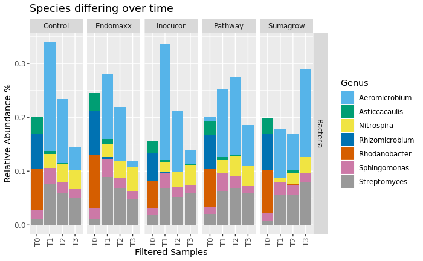

```r
#These are the feature importances >1% in the RandomForest analysis made on qiime2
time.importance <-read.delim('merged/models/randomforest/Timepoint_feature_importance.tsv') %>%
  separate(feature, c("Kingdom", "Phylum", "Class", "Order", "Family","Genus"), sep=';') %>%
  mutate_at(vars(Kingdom, Phylum, Class, Order, Family, Genus), funs(gsub(".*__", "",.))) %>%
  filter(importance>1e-2)
subset_taxa(rel.abund, Genus %in% time.importance$Genus &
            !Kingdom =='Unassigned' & !Kingdom =='Archaea') %>%
  psmelt() %>%
  group_by(TimePoint, Biostimulant, Kingdom, Genus) %>%
  summarize(mean=mean(Abundance, na.rm = TRUE)*100,
            stdev=sd(Abundance, na.rm = TRUE)) %>%
  ggplot() +
      aes(x=TimePoint, y = mean, fill=Genus) +
      geom_bar(stat = 'identity') +
      scale_fill_pander() +
      facet_grid(Kingdom~Biostimulant) +
      theme(axis.text.x=element_text(angle=90,hjust=1,vjust=0.5)) +
      labs(y = "Relative Abundance %", x = "Filtered Samples") +
  ggtitle('Species differing over time')
```

```r
Area_RF <- read.delim('merged/models/randomforest/Area_feature_importance.tsv') %>%
  separate(feature, c("Kingdom", "Phylum", "Class", "Order", "Family","Genus"), sep=';') %>%
  mutate_at(vars(Kingdom, Phylum, Class, Order, Family, Genus), funs(gsub(".*__", "",.))) %>%
  filter(importance>1e-2)

subset_taxa(rel.abund, Genus %in% Area_RF$Genus &
            !Kingdom =='Unassigned' & !Kingdom =='Archaea') %>%
  psmelt() %>%
  group_by(TimePoint, Area, Biostimulant, Kingdom, Genus) %>%
  summarize(mean=mean(Abundance, na.rm = TRUE),
            stdev=sd(Abundance, na.rm = TRUE),
            Area.mean = mean(Area, na.rm = TRUE),
            Area.stdev = sd(Area, na.rm = TRUE)) %>%
  write.csv('merged/models/randomforest/Area_RF.csv')
```